# Lending Club Loan Default Rate Prediction Project

Min Xiao

February 18, 2018

# OUTLINE

## Question Phase

ideas: * Predict loan status (classification problem)

## Model Phase

ideas: *Clean Data

*Explore Data + variable identification + variable analysis + missing value treatment + feature engineering + feature selection

*build a logistic regression model

*build tree based models

## Model Evaluation And Improvements

## Read Data

```r
loan <- read.csv("C:\\Users\\Min\\Desktop\\Capstone Project\\loan.csv", stringsAsFactors = FALSE)
loanT <- loan
```

We consider Default, Charged Off as default loan and Fully Paid as desirable loan and ignore everything else.

```r
# Remove extra description before the loan status
loan$loan_status <- gsub('Does not meet the credit policy. Status:', '', loan$loan_status)

#Only use the loans that are in "Default", "Charged Off", "Fully Paid" status
loan <- loan[which(loan$loan_status %in% c('Default', 'Charged Off', 'Fully Paid')), ]
```

## Explore Data

### Variable identification

#### Define Response

We reduce loan_status feature to a two level factor feature

```r
loan$loan_status <- ifelse(loan$loan_status =='Fully Paid', "Fully.Paid", "Default" )
#add the new feature
loan$loan_status <- factor(loan$loan_status,levels = c("Default","Fully.Paid"))

table(loan$loan_status)
```

```
##
##    Default Fully.Paid
##      47228     209711
```

We did a quick analysis regarding data balance

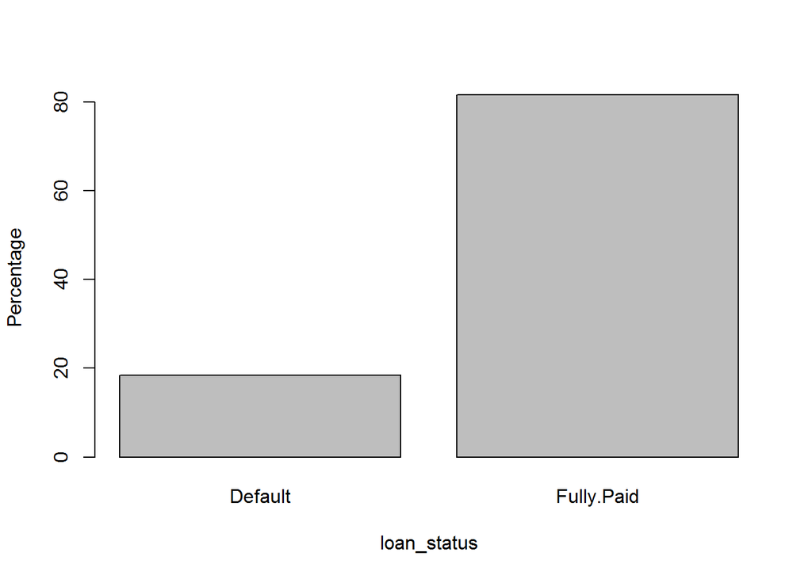

```r
percent <- by(loan, loan$loan_status, function(x) {return(dim(x)[1] / nrow(loan) * 100)})
barplot(percent, xlab ="loan_status", ylab = "Percentage")
```

```r
default_rate <- length(which(loan$loan_status == 'Default')) / dim(loan)[1] * 100
default_rate
```

```
## [1] 18.38102
```

As we can see,the data is moderately imbalanced.It is okay to process without any rebalance work.

### Other Possbile response variables with loan_status

#### grade with loan_status

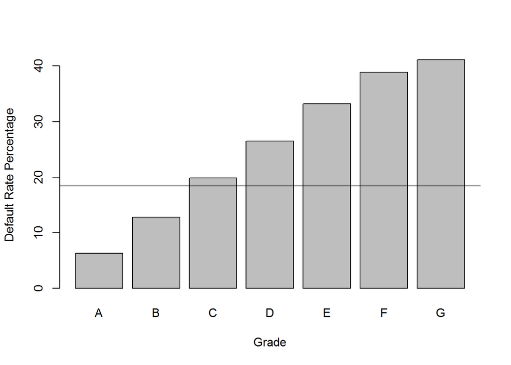

```r
default.rate.by.grade <- by(loan, loan$grade, function(x) {return(length(which(x$loan_status == 'Default')) / dim(x)[1] * 100)})

barplot(default.rate.by.grade, xlab ="Grade", ylab = "Default Rate Percentage")
abline(h=default_rate)
```

Clearly, We can see the default rate in different grade is different. The trend is the better the grade is, the lower default rate.

#### sub_grade with loan_status

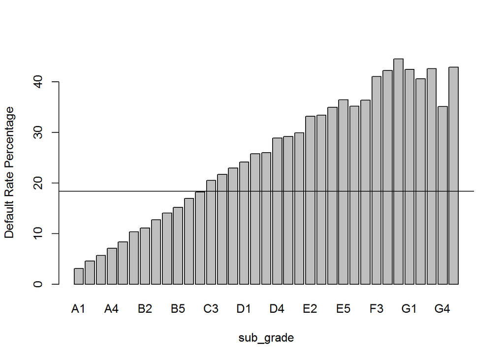

```r
default.rate.by.sub_grade <- by(loan, loan$sub_grade, function(x){return(length(which(x$loan_status == 'Default')) / dim(x)[1] * 100)})

barplot(default.rate.by.sub_grade, xlab ="sub_grade", ylab = "Default Rate Percentage")
abline(h=default_rate)
```

As we can see, the trend is the same as grade.

#### int_rate with loan_status

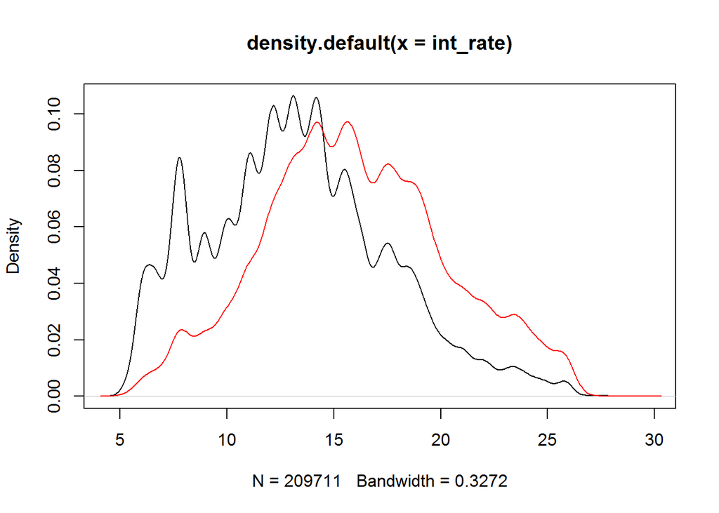

```r
with(subset(loan, loan_status == 'Fully.Paid'), plot(density(int_rate)))
with(subset(loan, loan_status == 'Default'), lines(density(int_rate), col = 'red'))
```

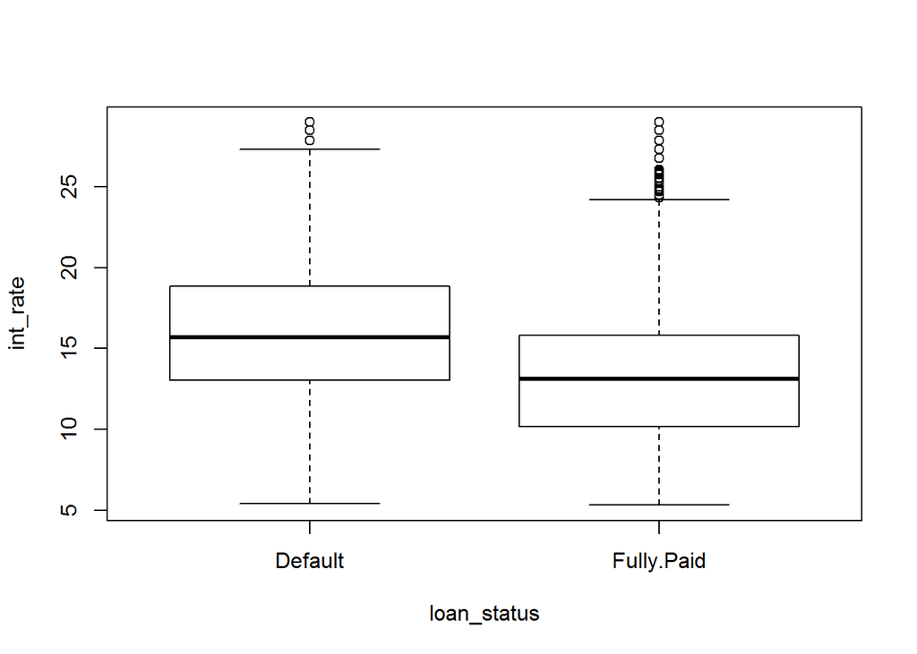

```r
boxplot(int_rate ~ loan_status, data = loan, xlab='loan_status', ylab='int_rate')
```

From the above two plots, we can clearly see default loans generally have higher interest rate.

### User Features (general)

#### addr_state with response

```r
library(choroplethr)
```

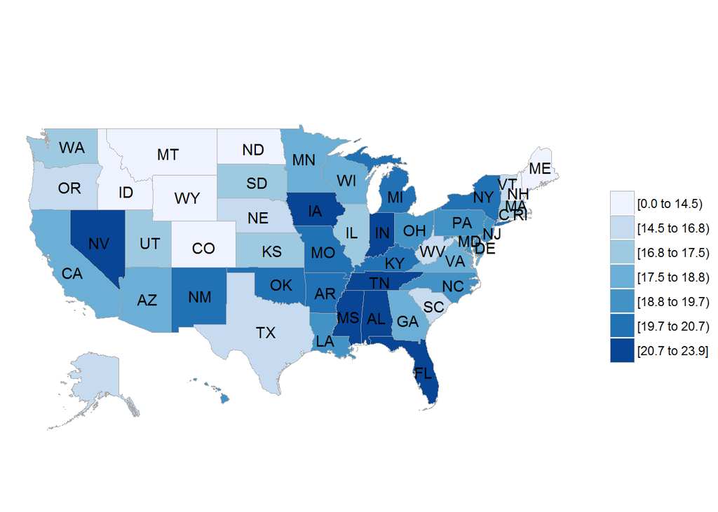

```r
library(choroplethrMaps)

#plot default rate by each state
state.default.rate <- as.list(by(loan, loan$addr_state, function(x){return(length(which(x$loan_status == 'Default')) / dim(x)[1] * 100)}))

state.names <- names(state.default.rate)
names(state.default.rate) <- NULL
state.int_rate.df <- data.frame(region = state.names, value = unlist(state.default.rate))

full.name = c()
for(i in 1:51)
{
    if(i==8){
        full.name <- append(full.name, "district of columbia")
    }else{
        full.name <- append(full.name, tolower(state.name[state.int_rate.df[i,1] == state.abb]))
    }
}

state.int_rate.df$region = full.name

options(repr.plot.width=16, repr.plot.height=8)
state_choropleth(state.int_rate.df)
```

There is no clear relationship between addr_state and default rate

We need to take a look at the number of loans in each state

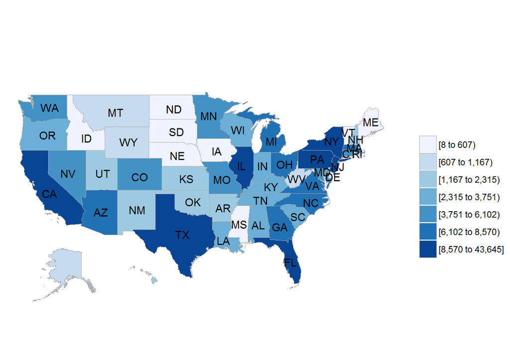

```r
#plot number of loans by state
state.loan.number <- as.list(by(loan, loan$addr_state, function(x){return(dim(x)[1])}))

state.names <- names(state.loan.number)
names(state.loan.number) <- NULL
state.int_rate.df <- data.frame(region = state.names, value = unlist(state.loan.number))

full.name = c()
for(i in 1:51)
{
    if(i==8){
        full.name <- append(full.name, "district of columbia")
    }else{
        full.name <- append(full.name, tolower(state.name[state.int_rate.df[i,1] == state.abb]))
    }
}

state.int_rate.df$region = full.name

options(repr.plot.width=16, repr.plot.height=8)
state_choropleth(state.int_rate.df)
```

Pattern is not clear here. We consider feature engineering, like binning, to reduce levels.

```r
# Feature engineering for addr_state > state_default_level
default_state <- by(loan, loan$addr_state, function(x){return(length(which(x$loan_status == 'Default')) / dim(x)[1] * 100)})
loan$state_default_level <- ifelse(loan$addr_state %in% names(default_state)[which(default_state <= quantile(default_state, 0.25))], 'low', ifelse(loan$addr_state %in% names(default_state)[which(default_state <= quantile(default_state, 0.5))], 'lowmedium', ifelse(loan$addr_state %in% names(default_state)[which(default_state <= quantile(default_state, 0.75))], 'mediumhigh', 'high')))
```

#### emp_length with loan_status

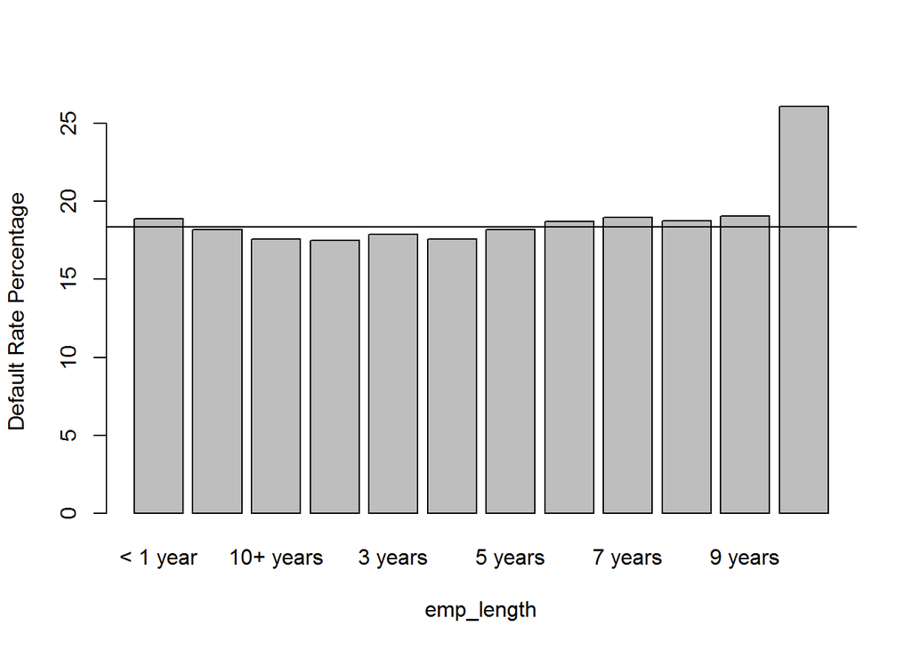

```r
default.rate.by.emp_length <- by(loan, loan$emp_length, function(x) {return(length(which(x$loan_status == 'Default')) / dim(x)[1] * 100)})


barplot(default.rate.by.emp_length, xlab ="emp_length", ylab = "Default Rate Percentage")
abline(h=default_rate)
```

There is no clear pattern for emp_length, but we can do some feature engineering to reduce levels.

```r
#featue engineering for emp_length
#divide into three groups based years '>5' '<=5', 'Missing'
loan$emp_length_sim <- ifelse(loan$emp_length %in% c('10+ years', '8 years','9 years','5 years','6 years','7 years'), '>= 5', ifelse(loan$emp_length %in% c('< 1 year', '1 year','2 years','3 years','4 years'), '< 5', 'Missing'))
```

#### emp_title with loan_status

```r
length(unique(loan$emp_title))
```

```
## [1] 134760
```

Too many levels, not relevant to response, just ignore it.

#### home_ownership with loan_status

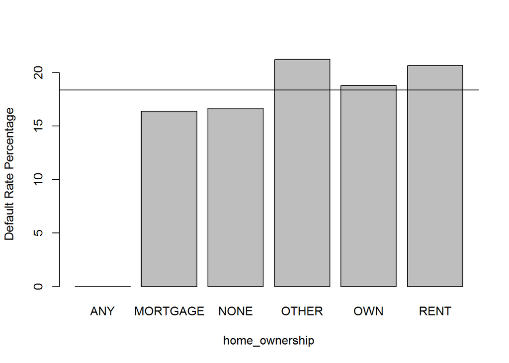

```r
default.rate.by.home_ownership <- by(loan, loan$home_ownership, function(x) {return(length(which(x$loan_status == 'Default')) / dim(x)[1] * 100)})

barplot(default.rate.by.home_ownership, xlab ="home_ownership", ylab = "Default Rate Percentage")
abline(h=default_rate)
```

The trend here is MORTGAGE < OWN < Rent < OTHER

We can do some feature engineering to combine some levels.

```r
#feature engineering for home_ownership
loan$home_ownership1 <- ifelse(loan$home_ownership %in% c('ANY', 'NONE', 'OTHER'), 'OTHER',
                              loan$home_ownership)
```

#### zip_code

```r
length(unique(loan$zip_code))
```

```
## [1] 889
```

Too many levels, going to ignore it for now.

### User features (financial specific)

#### annual_inc with loan_status

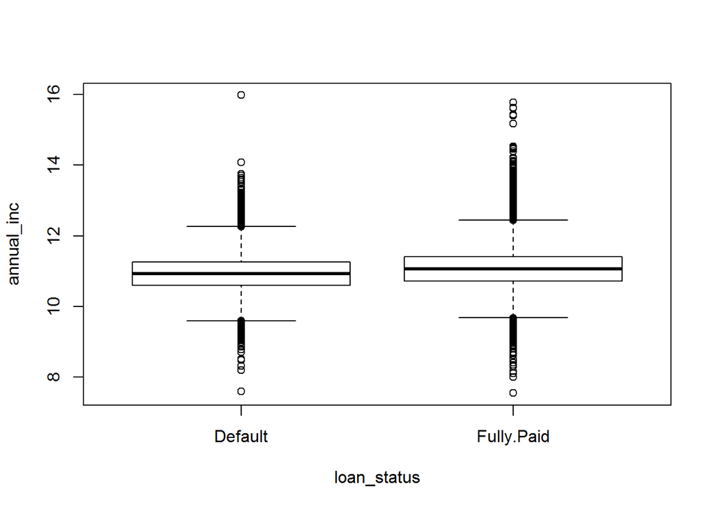

```r
boxplot(log(annual_inc + 1) ~ loan_status, data = loan, xlab='loan_status', ylab='annual_inc')
```

From the plot, we can see default group has slightly lower average annual_inc. We then do some feature engineering for annual_inc.

```r
#feature engineering for annual_inc
loan$annual_inc <- ifelse(!is.na(loan$annual_inc_joint), loan$annual_inc_joint, loan$annual_inc)

# missing value, impute with median
loan$annual_inc[which(is.na(loan$annual_inc))] <- median(loan$annual_inc, na.rm = T)

#option 1. take log
loan$log_annual_inc <- log(loan$annual_inc + 1)

#option 2. Divide by loan_amnt
loan$annual_inc_to_loan_amnt_percent <- loan$annual_inc / loan$loan_amnt * 100
```

#### verification_status with loan_status

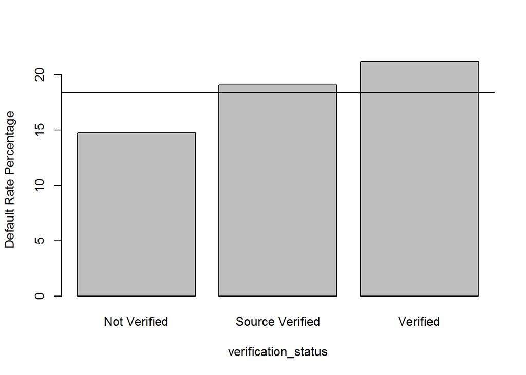

```r
default.rate.by.verification_status <- by(loan, loan$verification_status, function(x) {return(length(which(x$loan_status == 'Default')) / dim(x)[1] * 100)})

barplot(default.rate.by.verification_status, xlab ="verification_status", ylab = "Default Rate Percentage")
abline(h=default_rate)
```

Verified group has the highest default rate, which is contrary to intuition.

#### verification_status_joint

```r
table(loan$verification_status_joint)
```

```
##
##                 Source Verified
##          256938               1
```

verification_status_joint: most of them are empty string. Ignore this feature.

#### dti with loan_status

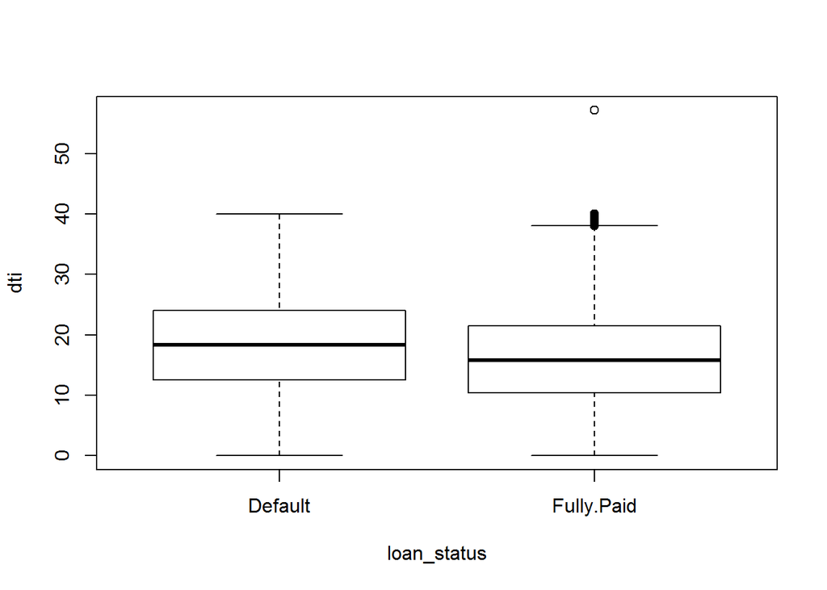

```r
boxplot(dti ~ loan_status, data = loan, xlab='loan_status', ylab='dti')
```

We can see default group has higher dti.

We merge dti_joint with dti.

```r
#feature engineering for dti
loan$dti <- ifelse(!is.na(loan$dti_joint), loan$dti_joint, loan$dti)
```

#### earliest_cr_line with response

```r
library(zoo)
as.Date(as.yearmon(loan$issue_d[1:5], "%b-%Y"))
```

```
## [1] "2011-12-01" "2011-12-01" "2011-12-01" "2011-12-01" "2011-12-01"
```

```r
loan$earliest_cr_line_date <- as.Date(as.yearmon(loan$earliest_cr_line, "%b-%Y"))
loan$earliest_cr_line_year <- format(loan$earliest_cr_line_date, '%Y')
```

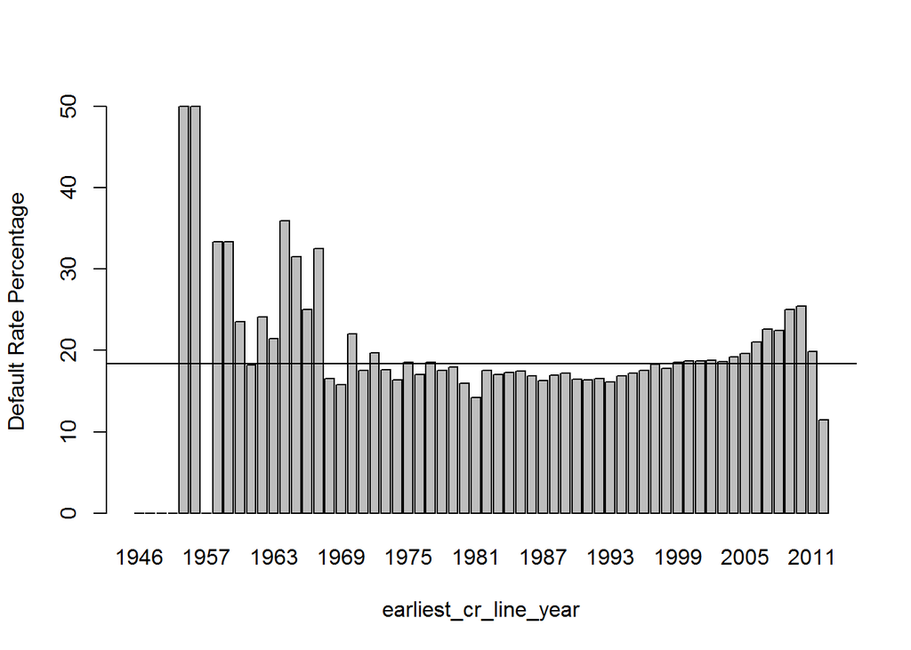

```r
default.rate.by.year <- by(loan, loan$earliest_cr_line_year, function(x) {return(length(which(x$loan_status == 'Default')) / dim(x)[1] * 100)})

barplot(default.rate.by.year, xlab ="earliest_cr_line_year", ylab = "Default Rate Percentage")
abline(h=default_rate)
```

There is some up and downs. No Clear pattern here.

#### inq_fi

```r
sum(is.na(loan$inq_fi))/dim(loan)[1]
```

```
## [1] 0.9994396
```

There are too many missing values.Although this feature (Number of personal finance inquiries ) seems important, we have to drop it.

#### inq_last_12m

```r
sum(is.na(loan$inq_last_12m))/dim(loan)[1]
```

```
## [1] 0.9994396
```

Drop this feature

#### inq_last_6mths with loan_status

```r
sum(is.na(loan$inq_last_6mths))
```

```
## [1] 29
```

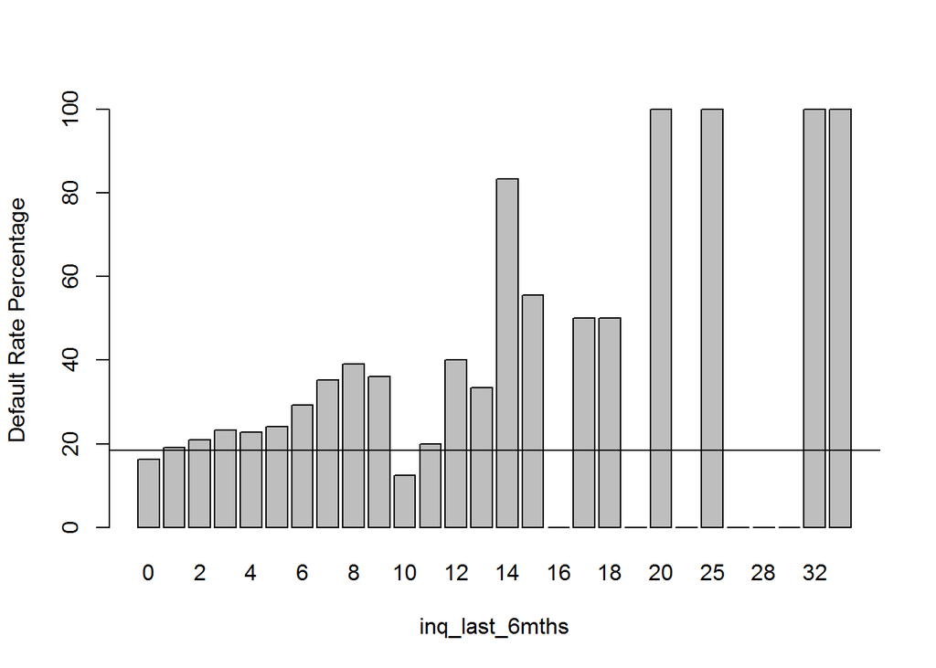

```r
default.rate.by.inq_last_6mths <- by(loan, loan$inq_last_6mths, function(x) {return(length(which(x$loan_status == 'Default')) / dim(x)[1] * 100)})

barplot(default.rate.by.inq_last_6mths, xlab ="inq_last_6mths", ylab = "Default Rate Percentage")
abline(h=default_rate)
```

There is general trend here, the more inquires, the higher default rate. The trend is more clear before 10. Also,data is sparse after 10.We will do some feature engineering here to reduce levels. Divide into 3 groups: 0, 1-5, >5

```r
#feature engineering for inq_last_6mths

#impute with median
loan$inq_last_6mths[which(is.na(loan$inq_last_6mths))] <- median(loan$inq_last_6mths, na.rm = TRUE)

loan$inq_last_6mths_level <- ifelse(loan$inq_last_6mths == 0, 'low', ifelse(loan$inq_last_6mths <= 5, 'medium', 'high'))
```

#### last_credit_pull_d with loan_status

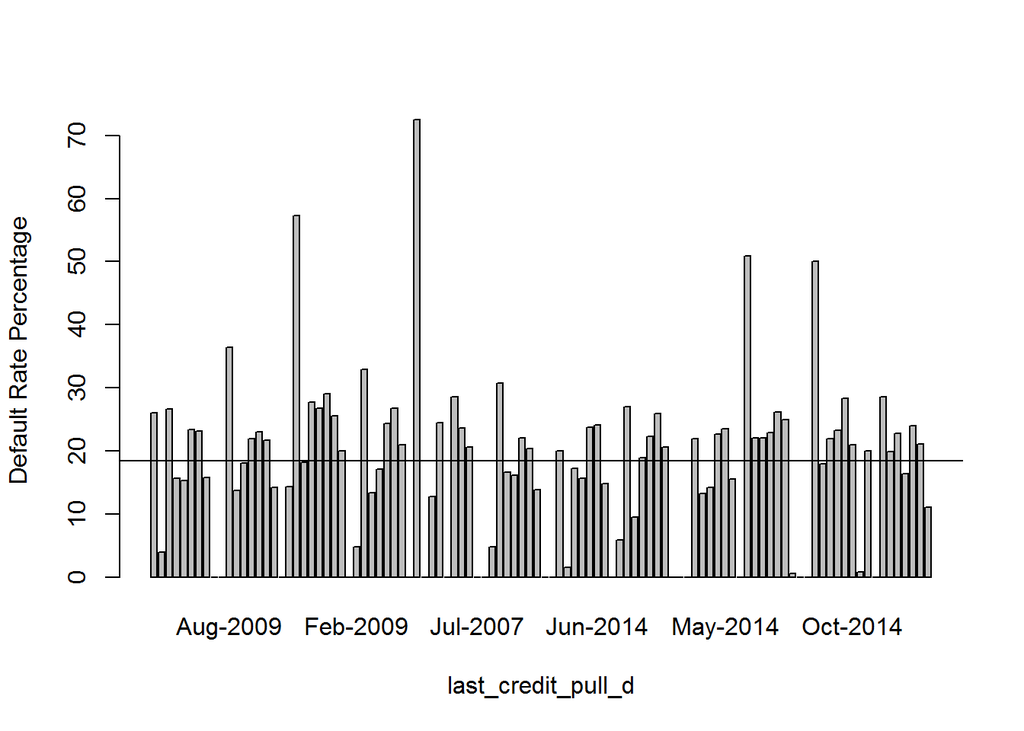

```r
default.rate.by.last_credit_pull_d <- by(loan, loan$last_credit_pull_d, function(x) {return(length(which(x$loan_status == 'Default')) / dim(x)[1] * 100)})

barplot(default.rate.by.last_credit_pull_d, xlab ="last_credit_pull_d", ylab = "Default Rate Percentage")
abline(h=default_rate)
```

No clear pattern here. Ignore this feature for now.

#### total_acc with loan_status

```r
sum(is.na(loan$total_acc))
```

```
## [1] 29
```

Plot

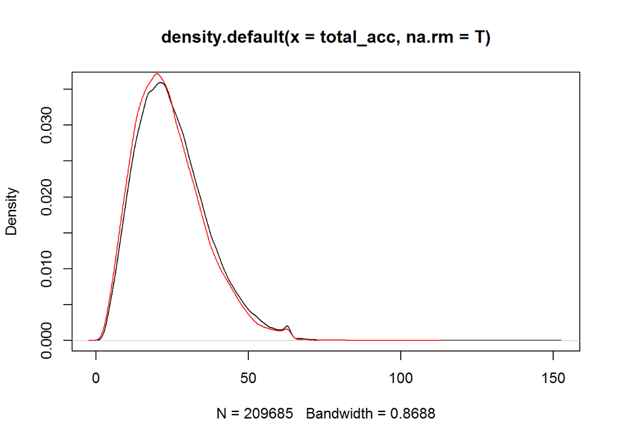

```r
with(subset(loan, loan_status == 'Fully.Paid'), plot(density(total_acc, na.rm = T)))
with(subset(loan, loan_status == 'Default'), lines(density(total_acc, na.rm = T), col = 'red'))
```

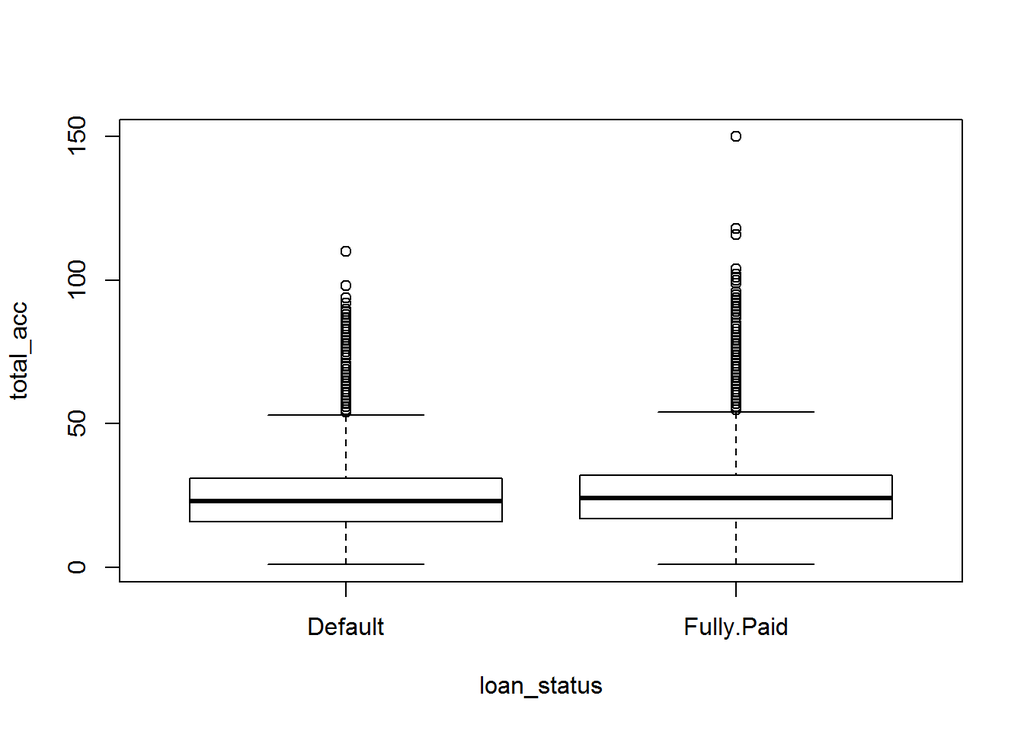

```r
boxplot(total_acc ~ loan_status, data = loan, xlab='loan_status', ylab='total_acc')
```

Although there is no much difference in the two groups for this feature, I will keep it in the initial try.

Impute missing value with median

```r
#Feature engineering for total_acc
loan$total_acc[which(is.na(loan$total_acc))] <- median(loan$total_acc, na.rm = T)
```

#### tot_cur_bal with loan_status

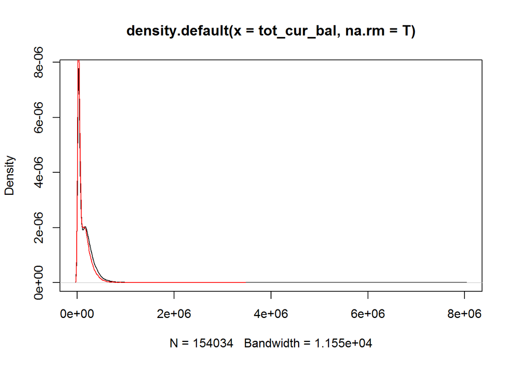

```r
with(subset(loan, loan_status == 'Fully.Paid'), plot(density(tot_cur_bal, na.rm = T)))
with(subset(loan, loan_status == 'Default'), lines(density(tot_cur_bal, na.rm = T), col = 'red'))
```

Take log for this feature

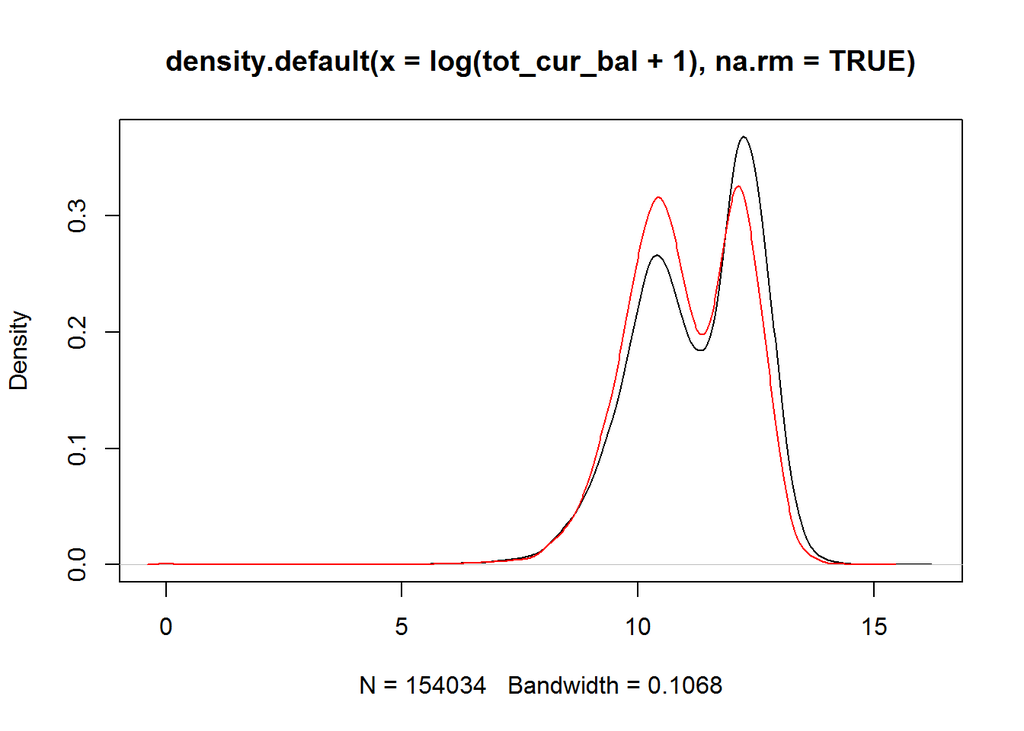

```r
with(subset(loan, loan_status == 'Fully.Paid'), plot(density(log(tot_cur_bal + 1), na.rm=TRUE)))
with(subset(loan, loan_status == 'Default'), lines(density(log(tot_cur_bal + 1), na.rm = T), col = 'red'))
```

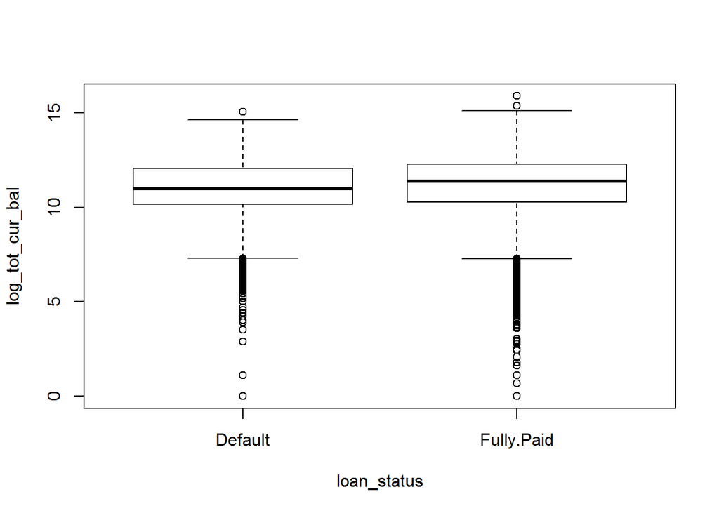

```r
boxplot(log(tot_cur_bal + 1) ~ loan_status, data = loan, xlab='loan_status', ylab='log_tot_cur_bal')
```

No obvious visual pattern, we will keep this feature as log form.

```r
#Feature engineering for tot_cur_bal

# missing value, impute with median
loan$tot_cur_bal[which(is.na(loan$tot_cur_bal))] <- median(loan$tot_cur_bal, na.rm = T)

#option 1. take log
loan$log_tot_cur_bal <- log(loan$tot_cur_bal + 1)

#option 2. Divide by loan_amnt
loan$tot_cur_bal_to_loan_amnt_percent <- loan$tot_cur_bal / loan$loan_amnt * 100
```

#### all_util

```r
sum(is.na(loan$all_util))/dim(loan)[1]
```

```
## [1] 0.9994396
```

Drop this feature

#### open_acc with loan_status

```r
sum(is.na(loan$open_acc))
```

```
## [1] 29
```

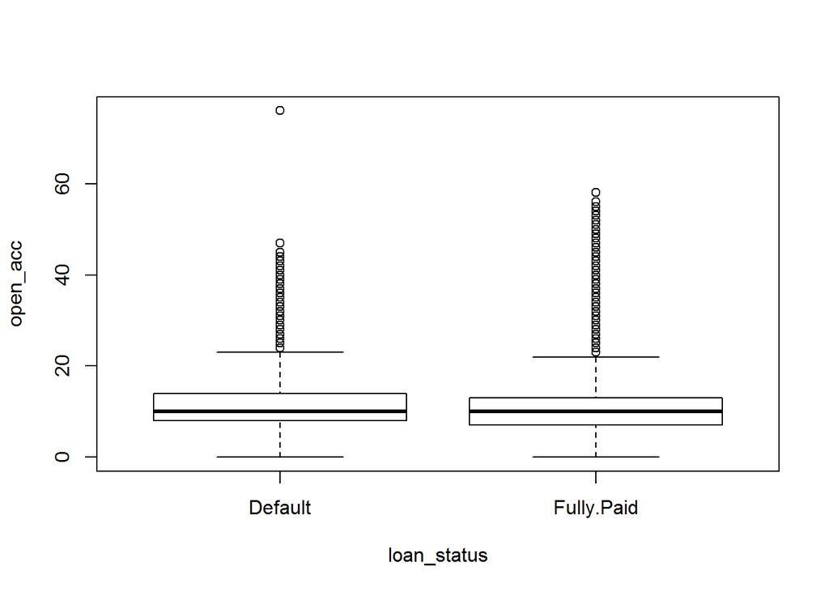

```r
boxplot(open_acc ~ loan_status, data = loan, xlab='loan_status', ylab='open_acc')
```

No clear difference between the two groups, we will keep this feature as it is.

Impute missing with median

```r
#Feature Engineering for open_acc
loan$open_acc[which(is.na(loan$open_acc))] <- median(loan$open_acc, na.rm = T)
```

#### open_acc_6m

```r
sum(is.na(loan$open_acc_6m))/dim(loan)[1]
```

```
## [1] 0.9994396
```

Drop this feature

#### total_cu_tl

```r
sum(is.na(loan$total_cu_tl))/dim(loan)[1]
```

```
## [1] 0.9994396
```

Drop this feature

#### acc_now_deling with loan_status

```r
sum(is.na(loan$acc_now_deling))
```

```
## [1] 0
```

```r
table(loan$acc_now_delinq)
```

```
##
##      0      1      2      3      4      5
## 256165    703     36      3      1      2
```

Most of records is zero. Convert this feature to a binary feature.

```r
#Feature engineering for acc_now_delinq
loan$acc_now_delinq[which(is.na(loan$acc_now_delinq))] <- 0
loan$acc_now_delinq <- ifelse(loan$acc_now_delinq == 0, 0, 1)
```

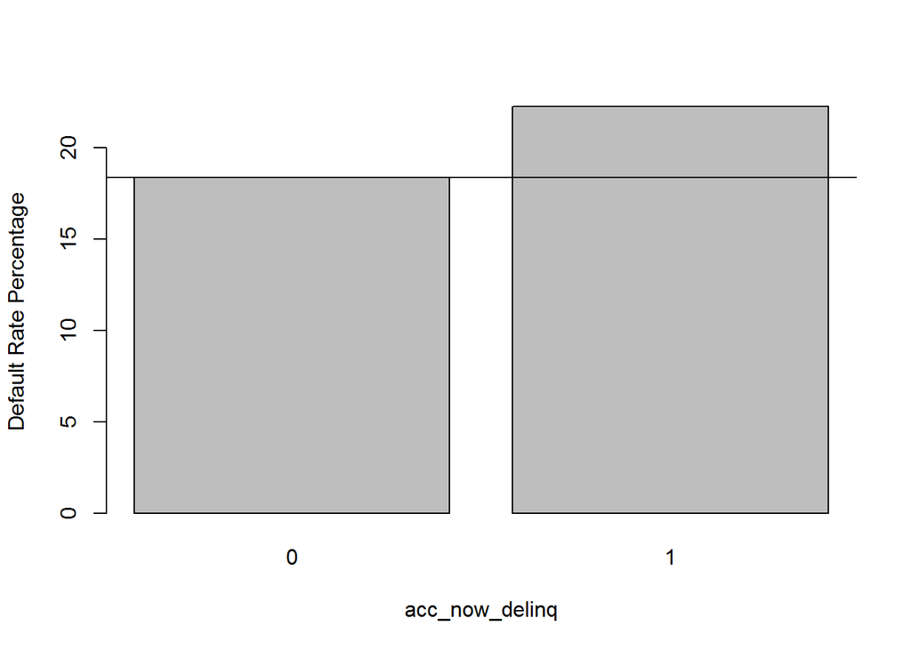

```r
default.rate.by.acc_now_delinq <- by(loan, loan$acc_now_delinq, function(x) {return(length(which(x$loan_status == 'Default')) / dim(x)[1] * 100)})

barplot(default.rate.by.acc_now_delinq, xlab ="acc_now_delinq", ylab = "Default Rate Percentage")
abline(h=default_rate)
```

From the plot, generally the more occurrences, the higher the default rate. We keep this feature as binary form.

#### delinq_2yrs with response

```r
sum(is.na(loan$delinq_2yrs))
```

```
## [1] 29
```

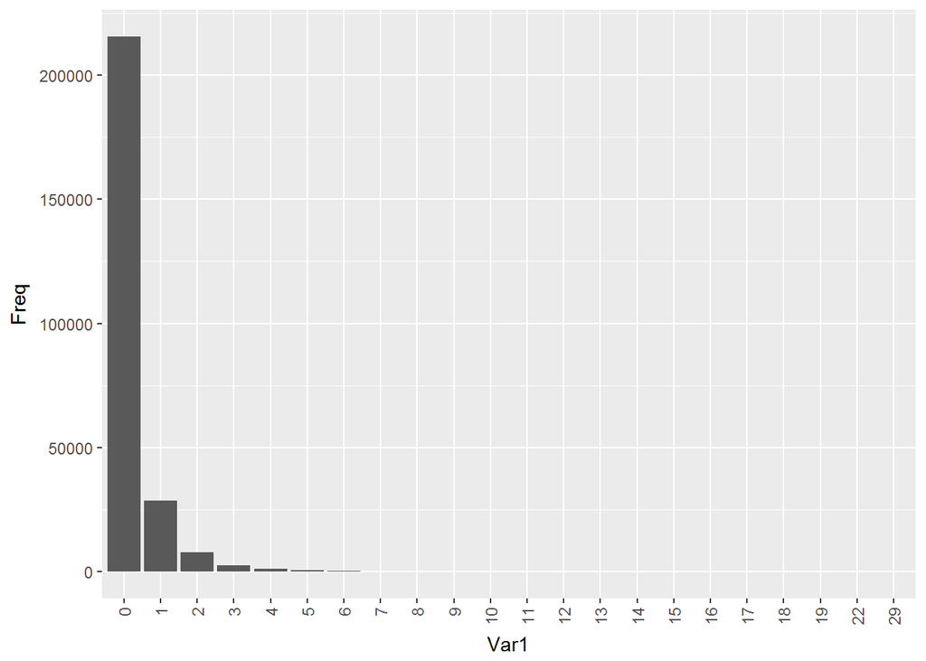

```r
library(ggplot2)
options(repr.plot.width=16, repr.plot.height=8)
ggplot(as.data.frame(table(loan$delinq_2yrs)), aes(x=Var1, y=Freq)) +
geom_bar(stat="identity") +
theme(axis.text.x = element_text(angle=90, hjust=1, vjust=.5),
        legend.position = "none")
```

Most records have value 0. We will do binning to three levels 0, 1-5, >5

```r
#Feature engineering for delinq_2yrs
#impute missing value with median
loan$delinq_2yrs[which(is.na(loan$delinq_2yrs))] <- median(loan$delinq_2yrs, na.rm = T)

loan$delinq_2yrs_level <- ifelse(loan$delinq_2yrs == 0, 'low', ifelse(loan$delinq_2yrs <= 5, 'medium', 'high'))
```

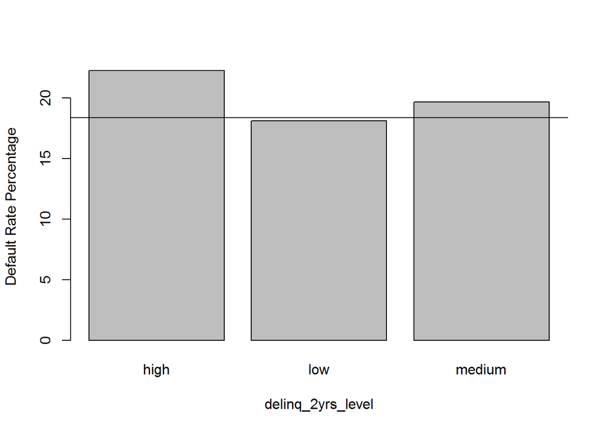

```r
default.rate.by.delinq_2yrs_level <- by(loan, loan$delinq_2yrs_level, function(x) {return(length(which(x$loan_status == 'Default')) / dim(x)[1] * 100)})

barplot(default.rate.by.delinq_2yrs_level, xlab ="delinq_2yrs_level", ylab = "Default Rate Percentage")
abline(h=default_rate)
```

#### mths_since_last_delinq with loan_status

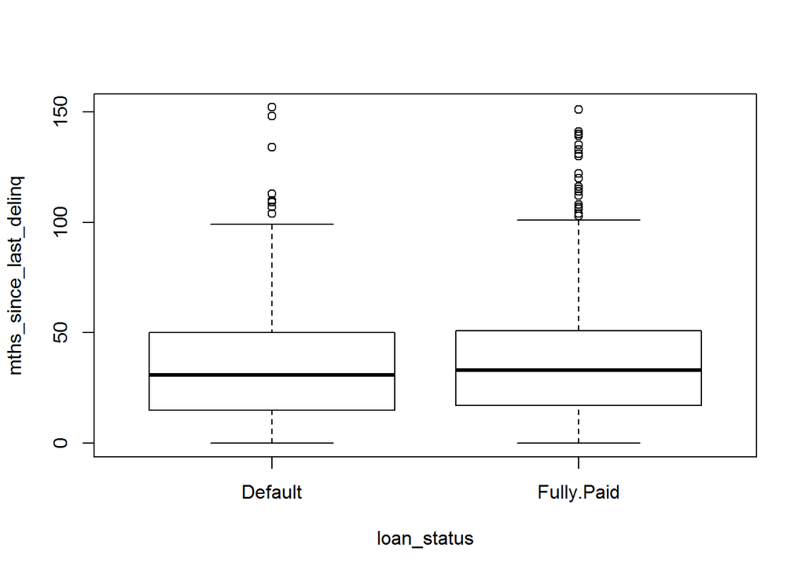

```r
boxplot(mths_since_last_delinq ~ loan_status, data = loan, xlab='loan_status', ylab='mths_since_last_delinq')
```

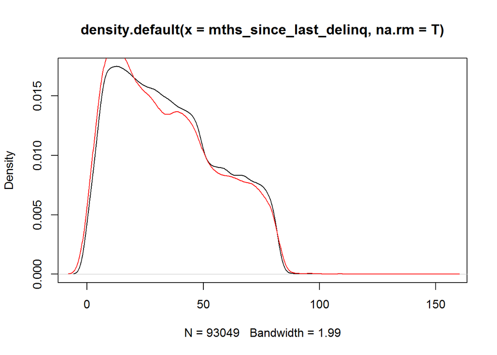

```r
with(subset(loan, loan_status == 'Fully.Paid'), plot(density(mths_since_last_delinq, na.rm=T)))
with(subset(loan, loan_status == 'Default'), lines(density(mths_since_last_delinq, na.rm=T), col = 'red'))
```

No difference between the two group.Going to drop this feature.

#### collections_12_mths_ex_med with loan_status

```r
sum(is.na(loan$collections_12_mths_ex_med))
```

```
## [1] 145
```

```r
table(loan$collections_12_mths_ex_med)
```

```
##
##      0      1      2      3      4      5      6
## 255201   1484     97      8      2      1      1
```

The data at bigger value is sparse. Reduce the levels to 3.

```r
#feature engineering for collections_12_mths_ex_med
#impute NA with zero, which is more reasonable
loan$collections_12_mths_ex_med[which(is.na(loan$collections_12_mths_ex_med))] <- 0

loan$collections_12_mths_ex_med <- ifelse(loan$collections_12_mths_ex_med == 0, 'low', ifelse(loan$collections_12_mths_ex_med ==  1, 'medium', 'high'))
```

#### tot_coll_amt with loan_status

```r
sum(is.na(loan$tot_coll_amt)) / dim(loan)[1]
```

```
## [1] 0.258719
```

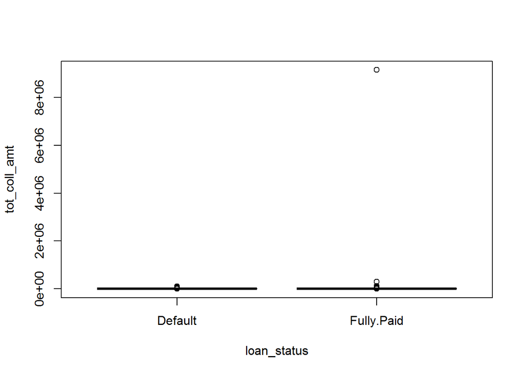

```r
boxplot(tot_coll_amt ~ loan_status, data = loan, xlab='loan_status', ylab='tot_coll_amt')
```

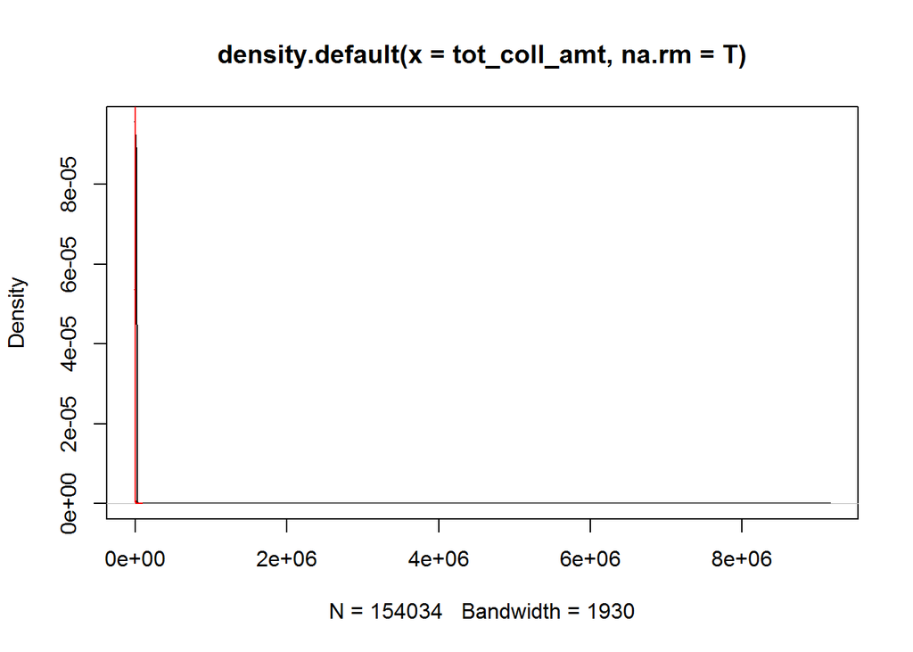

```r
with(subset(loan, loan_status == 'Fully.Paid'), plot(density(tot_coll_amt , na.rm = T)))
with(subset(loan, loan_status == 'Default'), lines(density(tot_coll_amt, na.rm = T), col = 'red'))
```

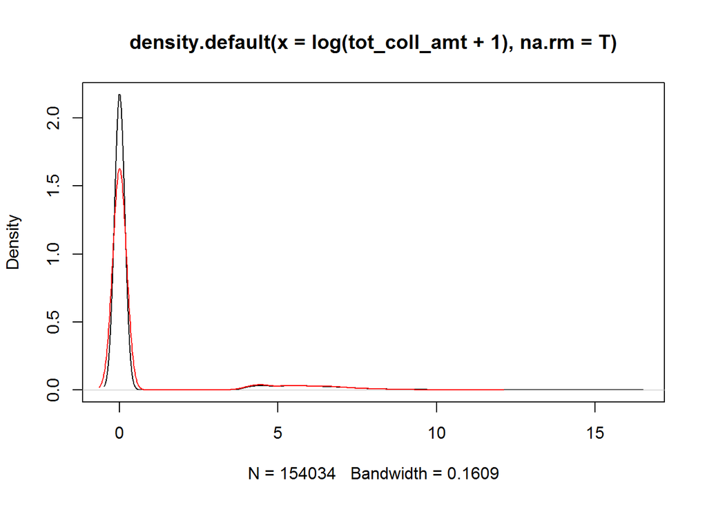

```r
with(subset(loan, loan_status == 'Fully.Paid'), plot(density(log(tot_coll_amt + 1), na.rm = T)))
with(subset(loan, loan_status == 'Default'), lines(density(log(tot_coll_amt + 1), na.rm = T), col = 'red'))
```

Drop this feature…

#### pub_rec

```r
sum(is.na(loan$pub_rec))
```

```
## [1] 29
```

```r
table(loan$pub_rec)
```

```
##
##      0      1      2      3      4      5      6      7      8      9
## 225511  27752   2583    687    204     94     39     19      8      5
##     10     11     12     15
##      5      1      1      1
```

Very sparse on the high end, we will do some binning to reduce levels

```r
#feature engineering for pub_rec

#impute missing value with median
loan$pub_rec[which(is.na(loan$pub_rec))] <- median(loan$pub_rec, na.rm = T)
loan$pub_rec <- ifelse(loan$pub_rec == 0, 'low', ifelse(loan$pub_rec < 3, 'medium', 'high'))
```

#### mths_since_last_major_derog

```r
sum(is.na(loan$mths_since_last_major_derog))/dim(loan)[1]
```

```
## [1] 0.8136678
```

Drop it.

#### mths_since_last_record

```r
sum(is.na(loan$mths_since_last_record))/dim(loan)[1]
```

```
## [1] 0.8728336
```

Drop it.

#### il_util

```r
sum(is.na(loan$il_util))/dim(loan)[1]
```

```
## [1] 0.9995096
```

Drop

#### mths_since_rcnt_il

```r
sum(is.na(loan$mths_since_rcnt_il))/dim(loan)[1]
```

```
## [1] 0.9994551
```

Drop

#### open_il_12m

```r
sum(is.na(loan$open_il_12m))/dim(loan)[1]
```

```
## [1] 0.9994396
```

Drop

#### open_il_24m

```r
sum(is.na(loan$open_il_24m))/dim(loan)[1]
```

```
## [1] 0.9994396
```

Drop

#### open_il_6m

```r
sum(is.na(loan$open_il_6m))/dim(loan)[1]
```

```
## [1] 0.9994396
```

Drop

#### total_bal_il

```r
sum(is.na(loan$total_bal_il))/dim(loan)[1]
```

```
## [1] 0.9994396
```

Drop

#### max_bal_bc

```r
sum(is.na(loan$max_bal_bc))/dim(loan)[1]
```

```
## [1] 0.9994396
```

Drop

#### open_rv_12m

```r
sum(is.na(loan$open_rv_12m))/dim(loan)[1]
```

```
## [1] 0.9994396
```

Drop

#### open_rv_24m

```r
sum(is.na(loan$open_rv_24m))/dim(loan)[1]
```

```
## [1] 0.9994396
```

Drop

#### revol_bal

```r
sum(is.na(loan$revol_bal))/dim(loan)[1]
```

```
## [1] 0
```

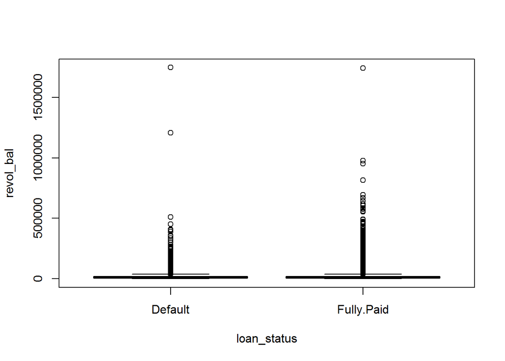

```r
boxplot(revol_bal ~ loan_status, data = loan, xlab='loan_status', ylab='revol_bal')
```

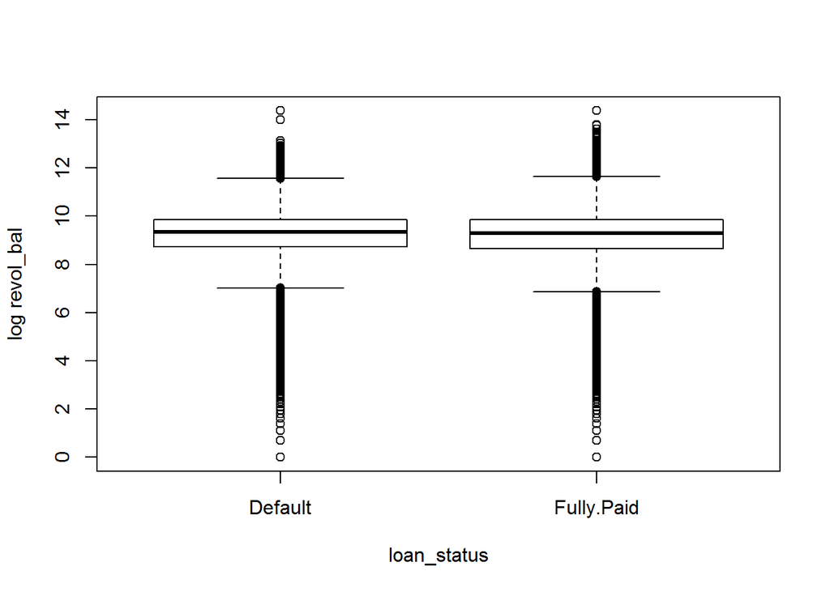

```r
boxplot(log(revol_bal + 1) ~ loan_status, data = loan, xlab='loan_status', ylab='log revol_bal')
```

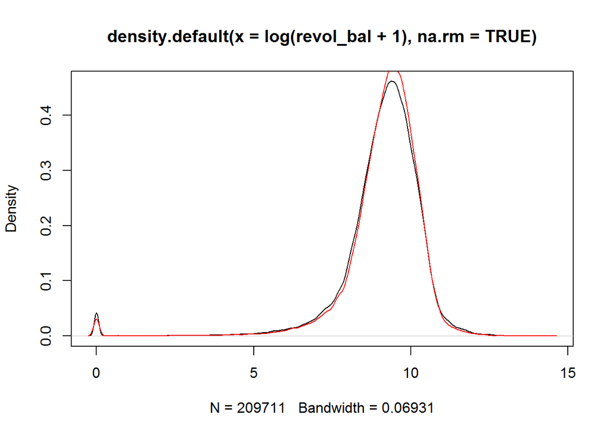

```r
with(subset(loan, loan_status == 'Fully.Paid'), plot(density(log(revol_bal + 1), na.rm=TRUE)))
with(subset(loan, loan_status == 'Default'), lines(density(log(revol_bal + 1), na.rm=T), col = 'red'))
```

There is no clear difference between default and non-default group.We just do some feature engineering.

```r
#Feature Engineering for revol_bal

#option 1. take log
loan$log_revol_bal <- log(loan$revol_bal + 1)

#option 2. Divide by loan_amnt
loan$revol_bal_to_loan_amnt_percent <- loan$revol_bal / loan$loan_amnt * 100
```